# Auxiliar 06 - Simplificación de Mallas

### CC5513 - Procesamiento Geométrico y Análisis de Formas

- Reduce el n° de vértices.
- Mantenemos la topología? O preferimos las características visuales?

## Objetivo/Contexto

En este auxiliar nos centraremos en ver formas de simplificar mallas, y en particular implementaremos un método para hacerlo, colapsando aristas según alguna métrica.

Archivo inicial:

```
import argparse
import os
import openmesh
import polyscope as ps

from util.simplification import simplification


def get_parser():
    parser = argparse.ArgumentParser(description="Mesh Simplification")
    parser.add_argument("-i", "--input", type=str, default='data/ankylosaurus.obj')
    parser.add_argument("--v", type=int, default=1000)
    parser.add_argument("--optim", action="store_true")
    args = parser.parse_args()
    return args


def main():
    args = get_parser()
    mesh_name = os.path.basename(args.input).split(".")[-2]

    original_mesh = openmesh.read_trimesh(args.input)
    simp2_mesh = simplification(original_mesh, target_v=args.v, valence_aware=args.optim)
    openmesh.write_mesh(f"data/output/{mesh_name}-simplificated-{args.v}.obj", simp2_mesh)


if __name__ == "__main__":
    main()
```

## Algunas formas de simplificar

### Vertex Clustering

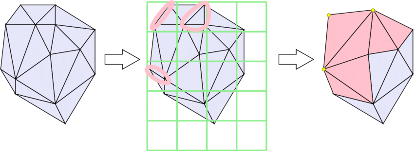

La idea es dividir el espacio donde se encuentra la malla. Cada celda forma un cluster de vértices, que colapsan en uno solo, simplificando rápidamente la malla.

- Qué pasa con la topología?
- Y si la malla no es muy regular?
- Cuántos vértices van a quedar?

### Vertex Decimation

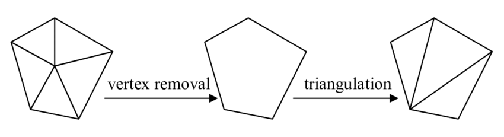

Nos preocupamos de elegir los vértices que vamos a eliminar. Cada vez que eliminamos uno, retriangulamos.

- Qué pasa con la topología?

### Edge Collapse

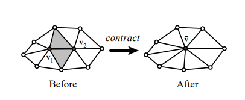

Nos preocupamos de elegir las aristas que vamos a eliminar. Es una eliminación de arista, seguida de una eliminación de uno de los vértices, y una retriangulación.

En realidad, se le llama colapso porque de alguna manera 'juntamos' los vértices en uno solo.

- Dónde los juntamos?
- Qué pasa con la topología?

### Pair Contraction

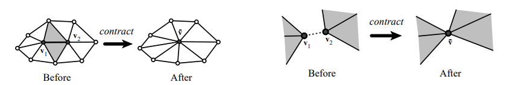

No sólo consideramos las aristas como en el Edge Collapse, sino que añadimos a nuestros candidatos todos los pares de vértices relativamente cercanos.

- Qué pasa con la topología?

## Ya, pero cómo decidimos qué eliminar/contraer?

### Decidir sobre la curvatura

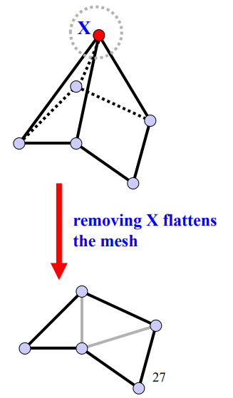

- Queremos realmente que nuestra simplificación aplane la malla?

### Distancia al plano promedio

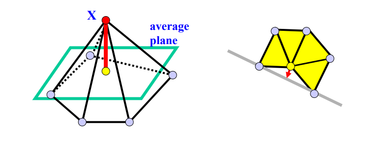

En vez de calcular una curvatura, podemos ver qué tanto dista del plano promedio que generan los vecinos de cada vértice.

### Utilizando Quadrics

La idea de Quadrics es tener un error asociado a la distancia de cada vértice a un plano correspondiente, $Q_v$ para cada vértice, que llamaremos *Quadric Error Metric*.

Lo interesante es que al tener esta métrica de error, podemos colapsar aristas de tal manera que se minimize el error del nuevo vértice. No intentamos eliminar los vértices con menor error, sino que procuramos colapsar aristas cuyos nuevos vértices tengan el menor error!

Hay dos maneras de colapsar aquí:

- Colapsar una arista hacia un vértice en el punto medio de sus extremos
- Colapsar una arista hacia un vértice que encima esté justo donde su error sería mínimo

## A implementar!

En este auxiliar, implementaremos una simplificación utilizando Iterative Edge Contraction, con la métrica de los [Quadric Errors](https://www.cs.cmu.edu/~./garland/Papers/quadrics.pdf).

Procuraremos conservar la topología haciendo Iterative Edge Contraction. En el paper de los Quadric Errors proponen el Pair contraction, colapsando incluso vértices que no estaban unidos!

Para implementar nuestra simplificación, primero necesitamos nuestro calculador de normales por cara, y además un calculador de los centros de cada cara. Esto último es similar a calcular normales por cara, pero esta vez para cada una en vez de promediar las normales de los vértices, promediamos los vértices en sí mismos.

**util/__init__.py**

```
# yup, vacio, es para que reconozca a 'util' como un python package
```

**util/normals.py**

```
import openmesh
import numpy as np


def compute_face_centers(mesh: openmesh.TriMesh):
    """
    Computes the centers per face

    :param mesh:
    :return: array with points
    """

    points = mesh.points()
    face_centers = np.zeros((mesh.n_faces(), 3))

    for face in mesh.faces():
        v_it = openmesh.FaceVertexIter(mesh, face)

        v0 = next(v_it).idx()
        v1 = next(v_it).idx()
        v2 = next(v_it).idx()

        face_centers[face.idx()] = np.sum([
            points[v0],
            points[v1],
            points[v2]], 0) / 3

    return face_centers


def compute_face_normals(mesh: openmesh.TriMesh):
    """
    Computes the normals per face

    :param mesh:
    :return: array with normals
    """

    points = mesh.points()
    normal_faces = np.zeros((mesh.n_faces(), 3))

    for face in mesh.faces():
        v_it = openmesh.FaceVertexIter(mesh, face)

        v0 = next(v_it).idx()
        v1 = next(v_it).idx()
        v2 = next(v_it).idx()

        normal = np.cross(points[v1] - points[v0],
                          points[v2] - points[v0])
        normal /= np.linalg.norm(normal)
        normal_faces[face.idx()] = normal

    return normal_faces


def calculate_vertex_normals(mesh: openmesh.TriMesh):
    """
    Calculates the normals per vertex via adding the face normals.

    :param mesh:
    :return: array with normals
    """
    normal_faces = compute_face_normals(mesh)

    normal_vertices = np.zeros((mesh.n_vertices(), 3))
    for vertex in mesh.vertices():
        face_it = openmesh.VertexFaceIter(mesh, vertex)
        for face in face_it:
            normal_vertices[vertex.idx(), :] += normal_faces[face.idx(), :]

        normal_vertices[vertex.idx(), :] /= np.linalg.norm(normal_vertices[vertex.idx(), :])

    return normal_vertices
```

Una vez tenemos eso, podemos partir con la obtención de datos necesarios para nuestra simplificación. Necesitaremos nuestros puntos de la malla, las caras, las normales de las caras y los centros.

**util/simplification.py**

```
import heapq

import openmesh
import numpy as np
import copy

from util.normals import compute_face_normals, compute_face_centers

def simplification(mesh: openmesh.TriMesh, target_v, valence_aware=True, midpoint=False):
    vs = mesh.points()
    vf = []
    vf_raw = np.array([item for item in mesh.vertex_face_indices()])
    for row in vf_raw:
        vf.append(set(row[row >= 0]))
    fn = compute_face_normals(mesh)
    fc = compute_face_centers(mesh)

    ...
```

También necesitaremos una lista de aristas.

```
...
    edges = []
    for edge in mesh.edges():
        # La idea es que sean tipo [v1_idx, v2_idx]
        he = mesh.halfedge_handle(edge, 0)
        edges.append(np.array([mesh.from_vertex_handle(he).idx(),
                               mesh.to_vertex_handle(he).idx()]))
    edges = np.array(edges)
    ...
```

### Preparando Q para cada vértice

Trabajaremos con un plano $ax+by+cz+d=0$. Recordemos que la ecuación de un plano centrado en el origen puede obtenerse como $<n, v>=0$, con $v$ un vector del plano, ya que este es necesariamente perpenducular con la normal.

#### Obtención de a, b, c y d:

Necesitamos obtener $a, b, c, d$. Pero si son conocidos la normal $n$ y un punto $C$ del plano (nuestro centro de un triángulo), podemos construir $v=X-C$, con $X=(x, y, z)$ un vector cualquiera del plano. $$ <n, v> = <n, X - C> = <n, X> - <n, C> $$ $$ ⇒\quad <n, (x, y, z)> - <n, C> = 0 $$

Por lo tanto, tenemos que $(a, b, c) = n$. La normal tiene nuestros valores buscados! Además, notemos que de la ecuación anterior, necesariamente $d=-<n,C>$

#### Obtención de Q de cada vértice

Utilizamos como medida de error la distancia del plano al vértice. Esta es precisamente sustituir el vértice en nuestra ecuación del plano como $av_x + bv_y + cv_z + d=$ distancia. Notemos que si la distancia es 0, obtenemos la ecuación del plano porque el punto pertenece al plano.

Esta ecuación puede ser escrita como $<p^T, v>$.

Podemos utilizar lo anterior para definir nuestra medida de error para cada vértice:

$$ \Delta(v) = \sum_{p \in N(v)}(p^T v)^2 $$

Lo bueno es que esto es muy simplificable, pues

$$ =\sum_{p \in N(v)}(v^T p)(p^T v) $$ $$ =v^T \left(\sum_{p \in N(v)}pp^T \right) v $$

Así, consideramos nuestro error $\Delta (v) = v^T Q v$.

```
...
    print("1. Compute Q for each vertex")
    Q_s = [[] for _ in range(len(vs))]
    E_s = [[] for _ in range(len(vs))]
    for i, v in enumerate(vs):
        f_s = np.array(list(vf[i]))
        fc_s = fc[f_s]
        fn_s = fn[f_s]

        d_s = - 1.0 * np.sum(fn_s * fc_s, axis=1, keepdims=True)
        abcd_s = np.concatenate([fn_s, d_s], axis=1)
        Q_s[i] = np.matmul(abcd_s.T, abcd_s)
        v4 = np.concatenate([v, np.array([1])])  # tiene que ser 4-D
        E_s[i] = np.matmul(v4, np.matmul(Q_s[i], v4.T))

    ...
```

### Obteniendo los errores de las contracciones de aristas

Ahora que tenemos los errores Q y E, podemos computar el error que tendría el vértice obtenido de colapsar cada arista.

Si tenemos Q1 y Q2 para los extremos de una arista, podemos usar $\bar{Q}=Q_1+Q_2$ para el $\bar{Q}$ correspondiente al vértice que quedaría entremedio. Con esta información, podemos procurar minimizar el error que quedaría de $\Delta(\bar{v})=\bar{v}^T Q \bar{v}$. Esto es de hecho resolver un sistema de ecuaciones.

- ¿Cómo obtendrías las aristas con menor error, de entre todas las aristas?

```
...
    print("2. Compute E for every possible pair and create heapq")

    E_heap = []
    # completar
    for i, e in enumerate(edges):
        v_0, v_1 = vs[e[0]], vs[e[1]]
        Q_0, Q_1 = Q_s[e[0]], Q_s[e[1]]
        Q_new = Q_0 + Q_1

        if midpoint:
            v_new = 0.5 * (v_0, v_1)
            v4_new = np.concatenate([v_new, np.array([1])])
        else:
            Q_lp = np.eye(4)
            Q_lp[:3] = Q_new[:3]
            try:
                Q_lp_inv = np.linalg.inv(Q_lp)
                v4_new = np.matmul(Q_lp_inv, np.array([[0, 0, 0, 1]]).reshape(-1, 1)).reshape(-1)
            except:
                v_new = 0.5 * (v_0 + v_1)
                v4_new = np.concatenate([v_new, np.array([1])])

        E_new = np.matmul(v4_new, np.matmul(Q_new, v4_new.T))
        heapq.heappush(E_heap, (E_new, (e[0], e[1])))
      ...
```

### Collapsing Edges

Lo primero que necesitaremos es listas de adyacencia de los vértices, además de dos máscaras que nos indiquen los vértices y las caras que hemos quitado cada vez que colapsamos una arista. Luego de eso, comenzaremos iterativamente a colapsar aristas hasta que tengamos el número de vértices que buscábamos. Esto es:

```
print("3. Collapse Minimum-error Vertex")
    simp_mesh = copy.deepcopy(mesh)
    simp_mesh_vf = copy.deepcopy(vf)
    simp_mesh_v2v = []
    for vh in simp_mesh.vertices():
        simp_mesh_v2v.append(sorted([neighbor.idx() for neighbor in simp_mesh.vv(vh)]))

    vi_mask = np.ones([len(simp_mesh.vertices())]).astype(bool)
    fi_mask = np.ones([len(simp_mesh.faces())]).astype(bool)

    while np.sum(vi_mask) > target_v:
        if len(E_heap) == 0:
            print("[WARNING]: Edge cannot be collapsed anymore!")
            break

        E_0, (vi_0, vi_1) = heapq.heappop(E_heap)

        if not (vi_mask[vi_0] and vi_mask[vi_1]):
            continue

        shared_vv = list(set(simp_mesh_v2v[vi_0]).intersection(set(simp_mesh_v2v[vi_1])))
        merged_faces = simp_mesh_vf[vi_0].intersection(simp_mesh_vf[vi_1])

        if len(shared_vv) != 2:
            """ non-manifold! """
            continue
        elif len(merged_faces) != 2:
            """ boundary """
            continue
        else:
            edge_collapse(simp_mesh, simp_mesh_vf, simp_mesh_v2v, vi_0, vi_1, merged_faces, vi_mask, fi_mask,
                          Q_s, E_heap, valence_aware=valence_aware)

    print("Finish.")

    simp_mesh.garbage_collection()  # so openmesh removes all discarded vertices and faces

    return simp_mesh
```

Pero cómo colapsamos aristas? Es un proceso que visualmente parece simple, pero que en realidad requiere sus detalles. Analicemos los siguientes casos!

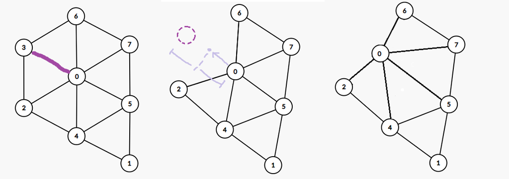

Vemos que en el dibujo de arriba, colapsar la arista que une los vértices v0 y v3 se puede hacer simplemente eliminando v3 y desplazando v0 hacia el medio. Pero este no es casi nunca el caso. Necesitamos un algoritmo más general, así que veamos el siguiente ejemplo.

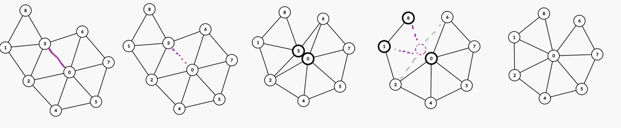

Notemos que, cuando queremos colapsar la arista (v0, v3), primero que nada estamos juntando ambos vértices hacia un punto central. Podemos quedarnos con v0 y cambiarle la posición hacia ese punto medio, así no hay que reconectar tantas cosas.

Pero luego de esto, cuando eliminamos v3, hay dos tipos de aristas que tenemos que considerar que salían de v3. Las marcadas en gris punteado son aristas que conectaban v3 con vértices que v0 también conectaba. Son aristas cuyos extremos eran vértices compartidos por v0 y v3!. No es necesario regenerarlas, porque v0 ya conecta con esos vértices.

Por otro lado, las aristas en morado son aquellas que iban de v3 a vértices que no estaban conectados con v0, así que son aristas que tenemos que reconectar, reemplazando v3 con v0.

```
def edge_collapse(simp_mesh: openmesh.TriMesh, simp_mesh_vf, simp_mesh_v2v, vi_0, vi_1, merged_faces, vi_mask, fi_mask,
                  Q_s, E_heap, valence_aware):

    simp_mesh.points()[vi_0] = 0.5 * (simp_mesh.points()[vi_0] + simp_mesh.points()[vi_1])
    simp_mesh.points()[vi_1] = np.copy(simp_mesh.points()[vi_0])
    simp_mesh.collapse(
        simp_mesh.find_halfedge(simp_mesh.vertex_handle(vi_1), simp_mesh.vertex_handle(vi_0))
    )

    # get shared vertices between vi_0 and vi_1, there should be 2
    shared_vv = list(set(simp_mesh_v2v[vi_0]).intersection(set(simp_mesh_v2v[vi_1])))

    # update faces:
    # - merge faces of vi_0 and vi_1 into vi_0, and remove all faces from vi_1
    simp_mesh_vf[vi_0] = simp_mesh_vf[vi_0].union(simp_mesh_vf[vi_1]).difference(merged_faces)
    simp_mesh_vf[vi_1] = set()
    # - remove the old merged faces from the shared_vv, the vertices that had connections with it
    simp_mesh_vf[shared_vv[0]] = simp_mesh_vf[shared_vv[0]].difference(merged_faces)
    simp_mesh_vf[shared_vv[1]] = simp_mesh_vf[shared_vv[1]].difference(merged_faces)
    # - mark merged faces as removed
    fi_mask[np.array(list(merged_faces)).astype(int)] = False

    # update vertices:
    new_vi_0 = set(simp_mesh_v2v[vi_0]).union(set(simp_mesh_v2v[vi_1])).difference({vi_0, vi_1})
    simp_mesh_v2v[vi_0] = list(new_vi_0)
    for v in simp_mesh_v2v[vi_1]:  # disconnect vi_1 neighbors form vi_1 and connnect them to vi_0
        if v != vi_0:
            simp_mesh_v2v[v] = list(set(simp_mesh_v2v[v]).difference({vi_1}).union({vi_1}))
    simp_mesh_v2v[vi_1] = []  # disconnect vi_1
    # - mark vi_1 as removed, while updating vi_0's position as the new merged vertex
    vi_mask[vi_1] = False

    Q_0 = Q_s[vi_0]
    for vv_i in simp_mesh_v2v[vi_0]:
        v_mid = 0.5 * (simp_mesh.points()[vi_0] + simp_mesh.points()[vv_i])
        Q_1 = Q_s[vv_i]
        Q_new = Q_0 + Q_1

        v4_mid = np.concatenate([v_mid, np.array([1])])

        E_new = np.matmul(v4_mid, np.matmul(Q_new, v4_mid.T))
        heapq.heappush(E_heap, (E_new, (vi_0, vv_i)))
```